# A Look at the Impact of Neutral Items on Professional DotA 2 Matches

## 1. Introduction

[Dota 2](http://blog.dota2.com/?l=english) is Valve's 2013 sequel to Defense of the Ancients, a custom game originally developed within the Warcraft 3 map editor. As a competitive game, Dota 2 pits two teams of five against each other in a contest to see which team can destroy the others "Ancient" first. Players select their character from a roster of over one-hundred ["Heroes"](http://www.dota2.com/heroes/) at the start of each game. Throughout the game, players seek to improve their character by leveling up and buying [items,](https://www.dota2.com/items/) with the ultimate goal of routing the enemy team.

The original mod fostered a grassroots competitive scene featuring local, player-organized leagues and tournaments. Popularity of the game boomed and the playerbase grew, increasing the size of the prize pools and fierceness of the competition. Valve's release of the sequel, Dota 2, coincided with their inaugural, flagship tournament, [The International.](https://liquipedia.net/dota2/The_International) Through a combination of prize money contributed by Valve and revenue generated through crowd-funding efforts, the purse for the tournament grows year-to-year, with the most recent International topping a total of $34 million. The tournament serves as a sort of end-goal for professional players.

The massive popularity of the game can be, in large part, attributed to the depth and intricacy of the gameplay that allows a skilled player dextrous control over the game and provides many different vectors for personal improvement. In short, the better player will most often come out on top. However, changes made in the most recent 7.23 update threaten to undermine the predominantly skill-based gameplay that have upheld Dota since its inception.

Players, and the majority of buildings and NPC's, are divided between two factions, the Radiant and the Dire. Much of the action in the game occurs as each faction marches down one of the three lanes dividing the playing field as they try to destroy the opposing base. The jungle, a wooded area occupying the space between the lanes, serves as a neutral repository of resources obtainable by either team. It's also home to a roster of neutral NPC's refered to as "neutral creeps". Prior to patch 7.23, killing neutral creeps only rewarded gold, the resource used to purchase various items within the game. However, the update attributed neutral creeps a chance to drop a "neutral item" on death.

Neutral items abide the following schema:

```
1. Chance to drop begins 7 minutes into the game
2. Items are divided into 5 tiers, each tier dropping within a certain time-frame in game.
3. Each team can only obtain one copy of a certain item
4. Each team can only obtain up to three items per tier
5. Item drop chance has diminishing returns per tier: 9% for the first item, 6% for the second, and 3% for the third
```

Items have long been an important portion of the game. Selection of the proper items to purchase, and when to purchase them, are a method of expressing skill and game knowledge. The abilities and powers of an item allow characters to adapt to different games. A player who knows what time their character will be the most powerful due to item timings will have a distinct advantage over those who don't. Playing to disrupt your opponents' timings opens windows for your team to build an advantage and win the game.

However, these aspects of gameplay are all deterministic, a direct result of players' input on the game and their opponents. The inclusion of neutral items introduces a new, random element that distinctly reduces player agenecy, and the importance of individual skill and teamwork. Maybe both teams see an equal number of powerful items drop throughout the game. Maybe one team gets lucky and sees all the item drops that game. There's also the chance the item that drops for your team isn't nearly as effective for your character as the item that dropped for the enemy is for theirs. These new facets of gameplay occur independently of player interaction, the incur the possibility of shifting the outcome of a game away from being completely player-generated. There is now the chance a team gained an advantage simply because they were lucky.

This tutorial will investigate the actual impact of these neutral items from a competitive standpoint by analyzing game data collected from professional matches that have been held since the patch.

## 2. Data Collection

Since Patch 7.23 released on November 26, 2019, the most premier professional matches have occured in the DreamLeague Season 13 qualifiers, a series of qualifying tournaments running up to the [DreamLeague Leipzig Major](https://liquipedia.net/dota2/DreamLeague/Season_13) that will take place this January. These games will serve as the data for our analysis.

Match data for Dota 2 is exposed through Valve's API, and is frequently collected and organized by various sites dedicated to the game. One such site, [OpenDota,](https://www.opendota.com/) provides an open source platform that we will use as our access point to these matches. We can use get requests to grab the data for each match from OpenDota.

```python
import requests
import json
import pprint

#Iterable arrays of match ID's. Divided into region so API calls can be done separately to avoid
#hitting OpenDota's rate limit.
na_match_ids = [5137306972, 5137371877, 5137426885, 5137477431, 5137530561, 5137574269, 5137601506,
                5137642597, 5137677181, 5137718830, 5138643023, 5138681468, 5138729875, 5138785851,
               5138844562, 5138871007, 5138918590, 5138949233, 5137292292, 5137358686, 5137407699,
               5137454538, 5137499660, 5137549090, 5137573873, 5137603069, 5137632061, 5137658906,
               5138635640, 5138709022, 5138755946, 5138798779, 5138848511, 5138890510, 5138911201,
               5138941590, 5138973903, 5138992583, 5140074679, 5140119117, 5140172554, 5140075998,
               5140115850, 5140147879, 5140221572, 5140259897, 5141370956, 5141429099, 5141482452,
               5141527129]

sa_match_ids = [5137052808, 5137136685, 5137240241, 5137298233, 5137356046, 5137413007, 5137459479,
               5137509637, 5137558526, 5137600152, 5139707294, 5138429862, 5138510303, 5138599462,
               5138683543, 5138754220, 5138813106, 5138846971, 5138884977, 5138913470, 5138947065,
               5137064410, 5137209549, 5137273490, 5137354773, 5137439257, 5137507309, 5137547213,
               5137585358, 5137616059, 5137647023, 5138438701, 5138528696, 5138624986, 5138671532,
               5138723473, 5138771466, 5138828632, 5138866995, 5138910620, 5138936886, 5138973593,
               5139784909, 5139857855, 5139924996, 5139988287, 5140033464, 5140085417, 5140120609,
               5140152858, 5141259090, 5141328439, 5141395858, 5141459106, 5141498317]

eu_match_ids = [5136643598, 5136714732, 5136845689, 5136992500, 5137101192, 5137172688, 5137239237,
               5137292234, 5137373223, 5137434625, 5138086147, 5138215291, 5138328117, 5138430124,
               5138522963, 5138573563, 5138663442, 5138729181, 5138790186, 5138830577, 5139381599,
               5139381599, 5136749012, 5136833266, 5136999146, 5137105566, 5137192050, 5137278156,
               5137353410, 5137399173, 5137459216, 5138084267, 5138166495, 5138244278, 5138330702,
               5138447201, 5138522501, 5138607628, 5138674869, 5138736880, 5138773034, 5138769910,
               5139847235, 5139912731, 5139997954, 5139628267, 5139724843, 5139617536, 5139708786,
               5139798722, 5139889143, 5139956476]

ru_match_ids = [5136479563, 5136618210, 5136702413, 5136824762, 5136953410, 5137035281, 5137100407,
               5137208352, 5137289131, 5137348550, 5137972601, 5138031619, 5138088204, 5138150284,
               5138224331, 5138336923, 5138436012, 5138512694, 5138611465, 5138657535, 5136481094,
               5136579531, 5136644403, 5136730943, 5136852863, 5136941942, 5137043675, 5137144103,
               5137250311, 5137333498, 5137972233, 5138024606, 5138082399, 5138160604, 5138246517,
               5138348372, 5138452765, 5138512390, 5138574045, 5138625256, 5138681402, 5139319450,
               5139395856, 5139484503, 5139566460, 5139704245, 5139814318, 5139878847, 5139944036,
               5140753686, 5140831554, 5140955990, 5141077128, 5141136727]

cn_match_ids = [5136117990, 5136162153, 5136232415, 5136285421, 5136384577, 5136486994, 5136568393,
               5136668451, 5136794596, 5136895700, 5137740649, 5137794482, 5137849920, 5137890306,
               5137957908, 5137991719, 5138037117, 5138092091, 5138167418, 5138256944, 5138337670,
               5136120590, 5136175287, 5136254238, 5136321611, 5136379847, 5136468633, 5136535616,
               5136596058, 5136683169, 5136769349, 5137738942, 5137786719, 5137850631, 5137921278,
               5137969448, 5138008904, 5138066431, 5138145719, 5138238683, 5138321338, 5139309341,
               5139364382, 5139163011, 5139202919, 5139252664, 5139165568, 5139212819, 5139325918,
               5139387453]

se_match_ids = [5136126181, 5136180529, 5136240154, 5136321512, 5136400752, 5136469164, 5136561703,
               5136634356, 5136729938, 5136830399, 5137739908, 5137781313, 5137828164, 5137879113,
               5137920002, 5137974099, 5138056429, 5138127876, 5138213024, 5138292751, 5138423876,
               5138430217, 5136125530, 5136174241, 5136242590, 5136300341, 5136373662, 5136447246,
               5136523209, 5136614335, 5136693207, 5136801900, 5137743364, 5137782097, 5137824607,
               5137869092, 5137914144, 5137964797, 5138019498, 5138080614, 5138158111, 5138251206,
               5139035978, 5139140391, 5139193392, 5139161632, 5139227250, 5139294691, 5139161726,
               5139217248, 5139373709, 5139464937, 5139566719]

json_objects = [] #Array used to store JSON objects returned from API calls
request = "https://api.opendota.com/api/matches/"
key = "my_key"

all_regions = [na_match_ids, sa_match_ids, eu_match_ids, ru_match_ids, cn_match_ids, se_match_ids]
for region in all_regions:
    for match_id in region:
        curr_id = str(match_id)
        r = requests.get(request + str(match_id) + key)
        json_objects.append(json.loads(r.text))
```

Each match is stored with an individual match ID. The ID's have been grouped by region above, as it simplified the process of issueing all the get requests without running into OpenDota's rate limit.

The get request is formed by iterating through each of the listed ID's and slotting it into the request function from Python's Requests library. The data is returned as a JSON string, which we convert into a JSON object and place into a new array as we accumulate the data from all the requests.

The JSON objects we've collected contain a lot of data, most of which isn't going to be relevant to an investigation on neutral items. We need to sift through and pull out the important pieces, however, the raw JSON isn't the most human readable format. The pprint library takes one of the JSON objects and transforms it into a format that will be easier to look over as we select what portions we'd like to keep.

```python
json_objects[0]
```

```
{'match_id': 5137306972,
 'barracks_status_dire': 3,
 'barracks_status_radiant': 63,
 'chat': None,
 'cluster': 123,
 'cosmetics': None,
 'dire_score': 4,
 'dire_team_id': 7409177,
 'draft_timings': None,
 'duration': 2117,
 'engine': 1,
 'first_blood_time': 217,
 'game_mode': 2,
 'human_players': 10,
 'leagueid': 11517,
 'lobby_type': 1,
 'match_seq_num': 4310600952,
 'negative_votes': 0,
 'objectives': None,
 '.......'
 'players': [{'match_id': 5137306972,
   'player_slot': 0,

   'ability_uses': None,
   'account_id': 108452107,
   'actions': None,
   'additional_units': None,
   'assists': 13,
   'backpack_0': 11,
   'backpack_1': 298,
   'backpack_2': 0,
   'backpack_3': 375,
   'buyback_log': None,
   'camps_stacked': None,
   'connection_log': None,
   'creeps_stacked': None,
   'damage': None,
   'damage_inflictor': None,
   'damage_inflictor_received': None,
   'damage_taken': None,
```

[output cut: 18 more lines]

```
   'item_4': 154,
   'item_5': 185,
   'item_uses': None,
   '........'
   'benchmarks': {'gold_per_min': {'raw': 724, 'pct': 0.9632606199770379},
    'xp_per_min': {'raw': 778, 'pct': 0.7749712973593571},
    'kills_per_min': {'raw': 0.2834199338686821, 'pct': 0.8323765786452354},
    'last_hits_per_min': {'raw': 11.195087387812944,
     'pct': 0.9827784156142365},
    'hero_damage_per_min': {'raw': 839.4331601322626,
     'pct': 0.8323765786452354},
    'hero_healing_per_min': {'raw': 0, 'pct': 0.9253731343283582},
    'tower_damage': {'raw': 9958, 'pct': 0.931113662456946},
    'stuns_per_min': {'raw': 0, 'pct': 0.001148105625717566},
    'lhten': {}}},
```

As a starting point, let's take a look at the number of neutral items the winning team had in comparison to the losing team. We can begin to assemble a DataFrame by sifting through the fields in the JSON object, as seen above.

At the top of the JSON object there's a field corresponding the match ID. That one should be self explanatory. Not too far under that is another field titled 'radiant_win' with a boolean value attached. This pertains the outcome of the game, and will be 'True' if the Radiant won, or 'False' if the Dire won.

Navigate to the 'players' field in the JSON, and we can see the breakdown for each individual player in the corresponding game. We can then iterate over each of the 10 players to see what items they had at the end of the game.

In Dota, each player can hold up to 6 active items at any one time, and up to 4 more inactive items in their "backpack". Each of the entries in the player field has subfields pertaining to item_0, item_1, backpack_0, backpack_1, and so on. However, items are stored in the JSON strings according to their in-game ID number. To find something more familiar, we can retrieve a list of properties about each item from [Valve's WebAPI](https://developer.valvesoftware.com/wiki/Steam_Web_API) and use that information to look at items by name, rather than by an ID.

The information retrieved about the items is similarly stored in a JSON string. Since we need to reference it frequently to check what each item in each match is, the corresponding item names and ID's have been transferred to a dictionary for faster lookup.

## 3. Organization

To consolidate the data relevant to an investigation on neutral items, certain elements from the JSON strings are selected and placed into a Pandas DataFrame. To start, we can choose to look at the items held by each player and split between neutral and normally obtained items within that set.

The algorithm displayed below iterates over each individaul match, and within each match iterates over the data pertaining to the individual players. For each player, the ID of each of their 6 active items and 4 inactive items are obtained and then converted into an actual name using the data stored in the Items Dictionary. The majority of neutral items were newly created and added to the game in Patch 7.23, resulting in their ID numbers being the largest (most recently added). However, some of the neutral items were previously in the game and removed at some point in time. The ID's for these re-added items don't fall into the set of ID's higher than the rest of the normal items, and needed to be identified prior to separating a player's items into normal and neutral categories.

Additionally, the data in the JSON string does not directly identify the team each player was on. Corroborating the 'persona' listed for each player with the official records of the matches shows that the first five players listed (player no. 0 - 4) represent the Radiant team, while the last five (player no. 5 - 9) represent the Dire team.

The final two columns seen in the DataFrame below contain the 'Last Hits' for each team throughout the game. This terminology refers to the number of NPC's each team killed. Unfortuntaly, the data point did not differentiate between enemy creeps and neutral creeps, with the latter being the only avenue of obtaining neutral items.

```python
#Request through Valve's API to get information on Items and Item ID's
r2 = requests.get("http://api.steampowered.com/IEconDOTA2_570/GetGameItems/v1?key=my_valve_key")
```

```python
items = json.loads(r2.text)
items_dict = {} #Dictionary for Items and ID's. Quicker lookup
item_wins = {} #Record wins for each item
item_losses = {} #Record losses for each item

#Fill dictionaries
for item in items['result']['items']:
    items_dict[item['id']] = item['name']
    item_wins[item['id']] = 0
    item_losses[item['id']] = 0

#Arrays that hold constants used to navigate JSON objects.
neutral_item_ids = [70, 71, 211, 212, 238, 239]
player_numbers = [0, 1, 2, 3, 4, 5, 6, 7, 8, 9]
item_numbers = [0, 1, 2, 3, 4, 5]
bp_numbers = [0, 1, 2, 3]
data = []

for match in json_objects:
    curr_match = [match['match_id']]
    dire_lh = 0
    radiant_lh = 0

    if match['radiant_win'] == True: #Get match winner
        curr_match.append("Radiant")
    else:
        curr_match.append("Dire")

    for player in player_numbers: #Collect item information for each player
        curr_items = []
        num_neutral_items = 0

        #Player's last hits
        if player <= 4:
            radiant_lh = radiant_lh + match['players'][player]['last_hits']
        else:
            dire_lh = dire_lh + match['players'][player]['last_hits']

        #Information on player's active items
        for item in item_numbers:
            curr_item_id = match['players'][player]['item_' + str(item)]

            #Fill out wins and losses for each item
            if not curr_item_id == None and not curr_item_id == 0:
                if player <= 4 and match['radiant_win'] == True:
                    item_wins[curr_item_id] = item_wins[curr_item_id] + 1
                elif player <= 4 and match['radiant_win'] == False:
                    item_losses[curr_item_id] = item_losses[curr_item_id] + 1
                elif player > 4 and match['radiant_win'] == True:
                    item_wins[curr_item_id] = item_wins[curr_item_id] + 1
                else:
                    item_losses[curr_item_id] = item_losses[curr_item_id] + 1

            #Convert ID of player's items to names. Uses 'Empty Slot' as placeholder for no item
            if not curr_item_id == None:
                if curr_item_id >= 287 or curr_item_id in neutral_item_ids:
                    num_neutral_items = num_neutral_items + 1
            if curr_item_id == 0 or curr_item_id == None:
                curr_items.append("Empty_slot")
            else:
                curr_items.append(items_dict[curr_item_id])

        #Do the same for a player's inactive items.
        for bp_item in bp_numbers:
            curr_bp_item_id = match['players'][player]['backpack_' + str(bp_item)]

            if not curr_bp_item_id == None and not curr_bp_item_id == 0:
                if player <= 4 and match['radiant_win'] == True:
                    item_wins[curr_bp_item_id] = item_wins[curr_bp_item_id] + 1
                elif player <= 4 and match['radiant_win'] == False:
                    item_losses[curr_bp_item_id] = item_losses[curr_bp_item_id] + 1
                elif player > 4 and match['radiant_win'] == True:
                    item_wins[curr_bp_item_id] = item_wins[curr_bp_item_id] + 1
                else:
                    item_losses[curr_bp_item_id] = item_losses[curr_bp_item_id] + 1

            if not curr_bp_item_id == None:
                if curr_bp_item_id >= 287 or curr_bp_item_id in neutral_item_ids:
                    num_neutral_items = num_neutral_items + 1
            if curr_bp_item_id == 0 or curr_bp_item_id == None:
                curr_items.append("Empty_Slot")
            else:
                curr_items.append(items_dict[curr_bp_item_id])

        curr_match.append(curr_items)
        curr_match.append(num_neutral_items)

    curr_match.append(radiant_lh)
    curr_match.append(dire_lh)
    data.append(curr_match) #Place all collected information in new array

#Create DataFrame for item and match information
df = pd.DataFrame(data, columns = ['Match_ID', "Victor", 'Radiant1', 'Items1', 'Radiant2', 'Items2',
                                   'Radiant3', 'Items3', 'Radiant4', 'Items4', 'Radiant5', 'Items5',
                                   'Dire1', 'Items6', 'Dire2', 'Items7', 'Dire3', 'Items8', 'Dire4',
                                   'Items9', 'Dire5', 'Items10', 'Radiant Last Hits', 'Dire Last Hits'])


#Create and populate DataFrame for item winrates
winrate_df = pd.DataFrame(columns=['Item ID', 'Item Name', 'Wins', 'Losses'])
for item in items_dict:
    winrate_df = winrate_df.append({'Item ID': item,
                                    'Item Name': items_dict[item],
                                    'Wins': item_wins[item],
                                    'Losses': item_losses[item]},
                                   ignore_index=True)

df.head()
```

|  | Match_ID | Victor | Radiant1 | Items1 | Radiant2 | Items2 | Radiant3 | Items3 | Radiant4 | Items4 | ... | Dire2 | Items7 | Dire3 | Items8 | Dire4 | Items9 | Dire5 | Items10 | Radiant Last Hits | Dire Last Hits |
| --- | --- | --- | --- | --- | --- | --- | --- | --- | --- | --- | --- | --- | --- | --- | --- | --- | --- | --- | --- | --- | --- |
| 0 | 5137306972 | Radiant | [item_satanic, item_greater_crit, item_black_k... | 3 | [item_power_treads, item_invis_sword, item_rod... | 2 | [item_force_staff, item_spirit_vessel, item_ma... | 0 | [item_travel_boots, item_blink, item_magic_wan... | 2 | ... | [item_veil_of_discord, item_boots, item_trusty... | 2 | [item_guardian_greaves, item_bloodstone, item_... | 3 | [item_bracer, item_cyclone, item_dust, item_ke... | 2 | [item_blink, item_black_king_bar, item_orb_of_... | 1 | 929 | 792 |
| 1 | 5137371877 | Dire | [item_phase_boots, item_arcane_ring, item_anci... | 2 | [item_ward_dispenser, item_boots, item_mekansm... | 0 | [item_phase_boots, item_radiance, item_enchant... | 2 | [item_ward_sentry, item_aether_lens, item_wind... | 1 | ... | [item_power_treads, item_black_king_bar, item_... | 1 | [item_blink, item_lotus_orb, item_vladmir, ite... | 1 | [item_satanic, item_power_treads, item_paladin... | 1 | [item_tranquil_boots, item_black_king_bar, ite... | 2 | 611 | 1051 |
| 2 | 5137426885 | Radiant | [item_broom_handle, item_guardian_greaves, ite... | 3 | [item_phase_boots, item_soul_ring, item_ultima... | 1 | [item_magic_wand, item_glimmer_cape, item_buck... | 2 | [item_maelstrom, item_sange_and_yasha, item_po... | 1 | ... | [item_guardian_greaves, item_blink, item_third... | 2 | [item_vambrace, item_armlet, item_phase_boots,... | 2 | [item_glimmer_cape, item_clumsy_net, item_anci... | 2 | [item_cyclone, item_tranquil_boots, item_force... | 1 | 768 | 630 |
| 3 | 5137477431 | Dire | [item_ward_dispenser, item_spider_legs, item_b... | 2 | [item_black_king_bar, item_blink, item_power_t... | 2 | [item_sange_and_yasha, item_talisman_of_evasio... | 2 | [item_tranquil_boots, item_wind_lace, item_vla... | 2 | ... | [item_hood_of_defiance, item_shivas_guard, ite... | 1 | [item_magic_wand, item_glimmer_cape, item_ward... | 0 | [item_heavens_halberd, item_skadi, item_phase_... | 1 | [item_radiance, item_power_treads, item_gem, i... | 1 | 783 | 887 |
| 4 | 5137530561 | Radiant | [item_lifesteal, item_power_treads, item_magic... | 1 | [item_broom_handle, item_magic_wand, item_phas... | 2 | [item_magic_wand, item_buckler, item_pipe, ite... | 1 | [item_boots, item_magic_wand, item_medallion_o... | 1 | ... | [item_crown, item_headdress, item_boots, item_... | 0 | [item_oblivion_staff, item_null_talisman, item... | 1 | [item_tranquil_boots, item_clumsy_net, item_ur... | 2 | [item_buckler, item_magic_wand, item_power_tre... | 1 | 572 | 452 |

5 rows × 24 columns

## 4. Data Analysis

The first comparison we'd like to make is that between victories of teams that held more neutral items, versus victories of teams with fewer neutral items. This provides a general indication of whether or not there is a relation between these neutral items and the outcome of the game. The algorithm below iterates over the rows of data collected into the DataFrame, and counts both instances where the team with more neutral items won and lost. Similarl data points are collected for games where a team won with an item differential greater than two, and again with an item differential greater than four.

```python
more_items = 0
less_items = 0

more_items_2 = 0
less_items_2 = 0

more_items_4 = 0
less_items_4 = 0

df['radiant_items'] = 0
df['dire_items'] = 0
for index, row in df.iterrows():
    #Calculate total neutral items owned by Radiant and Dire teams
    radiant_items = row['Items1'] + row['Items2'] + row['Items3'] + row['Items4'] + row['Items5']
    dire_items =row['Items6'] + row['Items7'] + row['Items8'] + row['Items9'] + row['Items10']
    df.loc[index, 'radiant_items'] = radiant_items
    df.loc[index, 'dire_items'] = dire_items

    #All matches
    if radiant_items > dire_items:
        if row['Victor'] == "Radiant":
            more_items = more_items + 1
        else:
            less_items = less_items + 1
    else:
        if row['Victor'] == "Dire":
            more_items = more_items + 1
        else:
            less_items = less_items + 1

    #Matches with an item differential of 2
    if radiant_items - dire_items >= abs(2):
        if radiant_items > dire_items:
            if row['Victor'] == "Radiant":
                more_items_2 = more_items_2 + 1
            else:
                less_items_2 = less_items_2 + 1
        else:
            if row['Victor'] == "Dire":
                more_items_2 = more_items_2 + 1
            else:
                less_items_2 = less_items_2 + 1

    #Matches with an item differential of 4
    if radiant_items - dire_items >= abs(4):
        if radiant_items > dire_items:
            if row['Victor'] == "Radiant":
                more_items_4 = more_items_4 + 1
            else:
                less_items_4 = less_items_4 + 1
        else:
            if row['Victor'] == "Dire":
                more_items_4 = more_items_4 + 1
            else:
                less_items_4 = less_items_4 + 1
```

The data points are then placed into bar charts to obtain a side by side comparison for the number of victories under each set of conditions. The Python library, Seaborn, is used to visualize each plot.

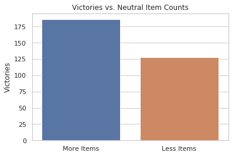

```python
import seaborn as sns

x = ['More Items', 'Less Items']
y = [more_items, less_items]
y2 = [more_items_2, less_items_2]
y4 = [more_items_4, less_items_4]

sns.set(style="whitegrid")
ax = sns.barplot(x, y)
ax.set(xlabel='', ylabel='Victories', title='Victories vs. Neutral Item Counts')
```

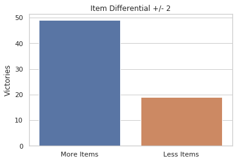

```python
ax2 = sns.barplot(x, y2)
ax2.set(xlabel='', ylabel='Victories', title='Item Differential +/- 2')
```

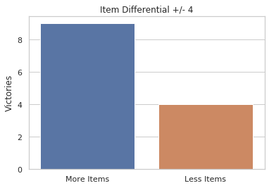

```python
ax4 = sns.barplot(x, y4)
ax4.set(xlabel='', ylabel='Victories', title='Item Differential +/- 4')
```

This set of charts reveals a distinct difference in the number of games won by teams with a greater number of neutral items compared to games won by teams with fewer neutral items. Without any other considerations, teams with more neutral items won over fifty additional games. As the sample was restricted to games with greater item differentials, a larger discrepancy can be seen. The team with the greater number of items won ~71% of games with at least a two item differential, and ~69% of the games with at least a four item differntial.

However, while this view might paint a general picture, there are some flaws to the approach. One, in particular, could be that the team in the lead would be stronger, thus being able to more freely move about the map. This would provide them access to a larger number of neutral creeps, and a higher chance at getting the neutral items in the first place. To account for this, we could consider the number of last hits a team obtained while collecting all of their neutral items. To inspect this, the approximate number of last hits per neutral item was calculated for each team in each match and placed in a new DataFrame. Then, a new set of plots was generated based upon whether the winning team had a higher or lower rate of creep kills required per neutral item drop.

```python
df2 = df[['Match_ID', 'Victor', 'radiant_items', 'Radiant Last Hits', 'dire_items', 'Dire Last Hits']].copy()
df2['radiant_ratio'] = 0
df2['dire_ratio'] = 0

lower_rate_win = 0
higher_rate_win = 0

lower200 = 0
higher200 = 0

for index, row in df2.iterrows():
    df2.loc[index, 'radiant_ratio'] = df2.loc[index, 'Radiant Last Hits'] / df2.loc[index, 'radiant_items']
    df2.loc[index, 'dire_ratio'] = df2.loc[index, 'Dire Last Hits'] / df2.loc[index, 'dire_items']

    #All matches
    if df2.loc[index, 'radiant_ratio'] > df2.loc[index, 'dire_ratio']:
        if df2.loc[index, 'Victor'] == "Dire":
            lower_rate_win = lower_rate_win + 1
        else:
            higher_rate_win = higher_rate_win + 1
    else:
        if df2.loc[index, 'Victor'] == "Radiant":
            lower_rate_win = lower_rate_win + 1
        else:
            higher_rate_win = higher_rate_win + 1

    #Matches where total last hits for each teams are within 25
    if df2.loc[index, 'Radiant Last Hits'] - df2.loc[index, 'Dire Last Hits'] < abs(25):
        if df2.loc[index, 'radiant_ratio'] > df2.loc[index, 'dire_ratio']:
            if df2.loc[index, 'Victor'] == "Dire":
                lower200 = lower200 + 1
            else:
                higher200 = higher200 + 1
        else:
            if df2.loc[index, 'Victor'] == "Radiant":
                lower200 = lower200 + 1
            else:
                higher200 = higher200 + 1
```

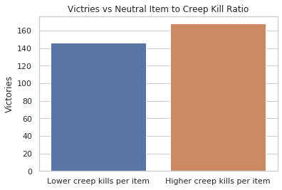

```python
x = ['Lower creep kills per item', 'Higher creep kills per item']
y = [lower_rate_win, higher_rate_win]

rate_ax = sns.barplot(x, y)
rate_ax.set(xlabel='', ylabel='Victories', title='Victries vs Neutral Item to Creep Kill Ratio')
```

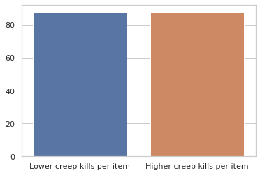

```python
y200 = [lower200, higher200]
rate_ax200 = sns.barplot(x, y200)
```

Strangely enough, the split was nearly down the middle, and showed slight favor to teams averaging more creep kills per item drop. As stated above, however, the most likely explanation for this observation is the fact that the data does not differentiate between enemy creep kills and neutral creep kills: they are shown in a single lump total. The calculated ratios would skew based on whether a team focused on killing enemy creeps or neutral creeps during the match.

The final point we can look at is the winrate of the invdividual neutral items. The algorithm below sums up the total number of appearances of an item against the total number of times it appeared, and calculates the winrate from these points.

```python
winrate_df = winrate_df.sort_values(by=['Item ID'])

winrate_df['Winrate'] = 0
for index, row in winrate_df.iterrows():
    wins = winrate_df.loc[index, 'Wins']
    losses = winrate_df.loc[index, 'Losses']
    total_games = wins + losses

    if total_games == 0:
        winrate_df.loc[index, 'Winrate'] = 0
    else:
        winrate_df.loc[index, 'Winrate'] = wins / total_games

neutral_df = winrate_df.loc[winrate_df['Item ID'] >= 287]
neutral_df = neutral_df.sort_values(by=['Winrate'], ascending=False)

neutral_df = neutral_df[neutral_df['Winrate'] != 0.0]

neutral_df.head()
```

|  | Item ID | Item Name | Wins | Losses | Winrate |
| --- | --- | --- | --- | --- | --- |
| 316 | 329 | item_recipe_vambrace | 5 | 2 | 0.714286 |
| 293 | 302 | item_elixer | 17 | 8 | 0.680000 |
| 344 | 377 | item_minotaur_horn | 14 | 7 | 0.666667 |
| 331 | 365 | item_panic_button | 13 | 8 | 0.619048 |
| 297 | 300 | item_timeless_relic | 11 | 7 | 0.611111 |

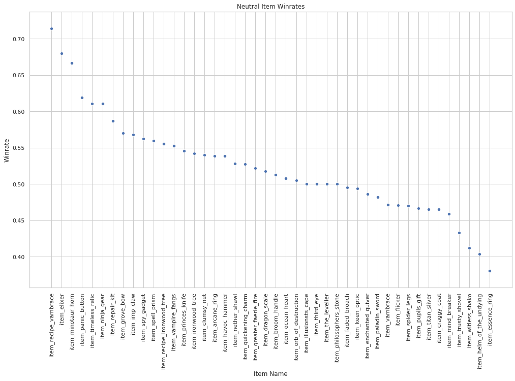

```python
import matplotlib.pyplot as plt

plt.figure(figsize=(17, 10))

wr_plot = sns.scatterplot(x='Item Name', y='Winrate', data=neutral_df).set_title('Neutral Item Winrates')
plt.xticks(rotation=90)
```

The plot above shows the win rate for each neutral item across all of the professional matches in the data set, with the highest being in the high 60%'s and even creeping into the low 70%'s. Additionally, the majority of the items had a winrate above 50%.

## 5. Conclusion

Although the charts investigating the rate of neutral items drops compared to creep kills didn't serve to elucidate much information, the remaining two visualizations provided an interesting perspective. Due to the large difference in the number of games won by teams with a greater quantity of neutral items, as well as the heightened winrates many of the items hold, it is plausible that the inclusion of neutral items does have an impact on professional Dota 2 matches.

The idea that an element as random as neutral item drops holds stake in the outcome of professional matches juxtaposes the core foundation of Dota 2 as a game built on the skill of the players and should be enough to serve as grounds for their removal. This also posits another question. What if the neutral items didn't have an impact on a game's outcome? To which, a proper answer might be, "Then what's the point?". If neutral items jeopardize a match's result with random elements when they are effective, and hold no power when not, I believe their inclusion (or removal) is a cleanly shut case.